# Finding ESM Subsets

acs

# Goal

from a selection of possible subset/chosen ESMs, come up with a metric for each of those subsets that says how good the subset is at representing the ‘truth’ that is the PCA of all of the CMIP6 data.

Then select the subset of ESMs with the smallest value for that metric and those are our ‘curated archive’ ESMs.

Work with this metric: The coefficients of all CMIP6 data into the first N eigenvectors from the PCA of all data. For each of the OOS esmXscenarios, for each subset ESM, calculate the smallest L2 distance from the coefficients across the subset ESM’s scenarios= how close each subset ESM can get to every out of sample data point. Then take the minimum across subset ESMs = how close the selected subset can get to each OOS data point. The average of that distance from all OOS data points is then the metric for that subset.

# set up

And some package and labeling info

```r
library(ggplot2)
library(dplyr)
library(tidyr)

metrics_dir <-  'extracted_timeseries/extracted_metrics/'
write_dir <- 'subset_summary_metrics/'
fig_dir <- 'figures/'

# ESMS that dont have 4 experiments
non_candidate_esm <- c("CIESM",
                       "E3SM-1-1", "FIO-ESM-2-0", "GFDL-CM4", "IITM-ESM",
                       "IPSL-CM5A2-INCA", "KIOST-ESM", "NESM3", "NorESM2-LM")


# Figure sizing info
title_size <- 14
axis_size <- 12
```

# Load ESM data that’s been processed

```r
region_summary_main <- read.csv(paste0(metrics_dir, 'IPCC_land_regions_metrics.csv'),
                                stringsAsFactors = FALSE)
region_summary_main %>%
  filter(experiment != 'ssp119',
         experiment != 'ssp434',
         experiment != 'ssp460',
         experiment != 'ssp534-over',
         !(esm %in% non_candidate_esm))  %>% # remove from the full set of data
                                             # that creates our 'true' CMIP6 PCA space
    rename(region = acronym) ->
  region_summary

print(head(region_summary))
```

```
##          esm experiment ensemble variable       type              name region
## 1 ACCESS-CM2     ssp126 r1i1p1f1       pr       Land Arabian-Peninsula    ARP
## 2 ACCESS-CM2     ssp126 r1i1p1f1       pr       Land    Central-Africa    CAF
## 3 ACCESS-CM2     ssp126 r1i1p1f1       pr Land-Ocean         Caribbean    CAR
## 4 ACCESS-CM2     ssp126 r1i1p1f1       pr       Land       C.Australia    CAU
## 5 ACCESS-CM2     ssp126 r1i1p1f1       pr       Land   C.North-America    CNA
## 6 ACCESS-CM2     ssp126 r1i1p1f1       pr       Land            E.Asia    EAS
##           iasd      end_val   end_anomaly end_anomaly_pct mid_century_val
## 1 7.227917e-07 1.700625e-06  4.306991e-07     0.339153029    2.051770e-06
## 2 3.009324e-06 4.828026e-05 -4.965491e-08    -0.001027416    4.941042e-05
## 3 6.106140e-06 3.052769e-05  2.089845e-07     0.006892922    3.429079e-05
## 4 2.830779e-06 1.130480e-05 -1.269868e-06    -0.100986213    1.126320e-05
## 5 2.861294e-06 3.232150e-05  1.953880e-06     0.064340892    3.222543e-05
## 6 2.687448e-06 5.449186e-05  5.826705e-06     0.119730531    5.260652e-05
##     mid_anomaly mid_anomaly_pct
## 1  7.818446e-07      0.61566180
## 2  1.080502e-06      0.02235680
## 3  3.972086e-06      0.13101110
## 4 -1.311461e-06     -0.10429388
## 5  1.857811e-06      0.06117738
## 6  3.941364e-06      0.08098944
```

# Prep data for PCA

```r
# reshape:
grouped_data <- split(region_summary, list(region_summary$esm, region_summary$experiment))
grouped_data <- grouped_data[sapply(grouped_data, function(x) dim(x)[1]) > 0]

shaped_data <- lapply(grouped_data, function(group){
    if (nrow(group) >0) {
      group %>%
        filter(variable == 'tas') %>%
        select(esm, experiment, ensemble,type, region,
               iasd, end_anomaly, mid_anomaly) %>%
        rename(tas_iasd = iasd,
               tas_end_anomaly = end_anomaly,
               tas_mid_anomaly = mid_anomaly) %>%
        left_join(group %>%
                      filter(variable == 'pr') %>%
                      select(esm, experiment, ensemble,type, region,
                             iasd, end_anomaly_pct, mid_anomaly_pct) %>%
                      rename(pr_iasd = iasd,
                             pr_end_anomaly_pct = end_anomaly_pct,
                             pr_mid_anomaly_pct = mid_anomaly_pct),
                  by = c('esm','experiment', 'ensemble', 'type', 'region')
               ) ->
    reshaped

    reshaped %>%
        group_by(esm, experiment, type, region) %>%
        summarize(tas_iasd=mean(tas_iasd),
                  tas_end_anomaly=mean(tas_end_anomaly, na.rm = T),
                  tas_mid_anomaly = mean(tas_mid_anomaly, na.rm = T),
                  pr_iasd = mean(pr_iasd, na.rm = T),
                  pr_end_anomaly_pct = mean(pr_end_anomaly_pct, na.rm = T),
                  pr_mid_anomaly_pct = mean(pr_mid_anomaly_pct, na.rm = T) ) %>%
        ungroup() %>%
        mutate(ensemble = 'ensemble_avg') -> #%>%
        #bind_rows(reshaped) ->
        reshaped2

    #TODO need to change shaping if including ensemble members
    reshaped2 %>%
        select(-type) %>%
        gather(metric, value, -esm, -experiment, -ensemble, -region) %>%
        mutate(row_id = paste0(region, '~', metric),
           col_id = paste0(esm, '~', experiment, '~', ensemble)) %>%
        select(-esm, -experiment,-ensemble, -region, -metric) %>%
        as.data.frame() ->
    reshaped3

  colnames(reshaped3) <- c(paste0(unique(reshaped3$col_id)), 'row_id', 'col_id')
  rownames(reshaped3) <- paste0(reshaped3$row_id)

  reshaped3 %>%
    select(-col_id, -row_id) ->
    out

  return(out)
    }

    }
)

# combine columns but then transpose because prcomp wants rows to be observations
# and columns to be variables (but doing it the other way first is easier to code)
full_data <- t(do.call(cbind, shaped_data) )


# Drop anything with missing data
full_data1 <- na.omit(full_data)
print('removed rows due to missing data')
```

```
## [1] "removed rows due to missing data"
```

```r
print(row.names(full_data)[c(which(!(row.names(full_data) %in% row.names(full_data1))))])
```

```
## character(0)
```

```r
full_data <- as.data.frame(full_data1)
rm(full_data1)
```

# PCA

## cmip6 ‘truth’

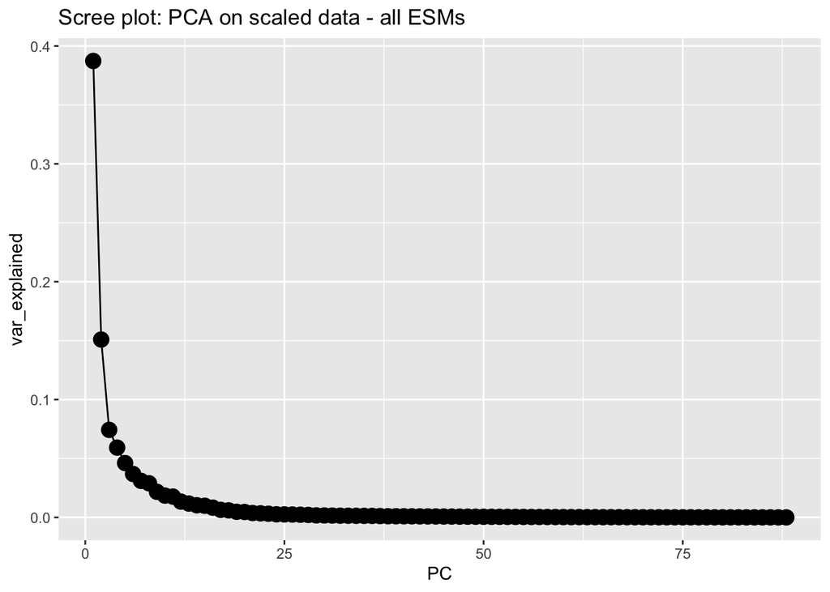

```r
full_pca <- prcomp(full_data, center=TRUE, scale = TRUE)


# eigenspace from the PCA
full_eigenval <- data.frame(eigenvalues=(full_pca$sdev)^2)
full_eigenvec <- full_pca$rotation

# skree
var_explained_df <- data.frame(var_explained=(full_pca$sdev)^2/sum((full_pca$sdev)^2)) %>%
    mutate(PC = as.integer(row.names(.)))

var_explained_df %>%
  ggplot(aes(x=PC,y=var_explained, group=1))+
  geom_point(size=4)+
  geom_line()+
  labs(title="Scree plot: PCA on scaled data - all ESMs")
```

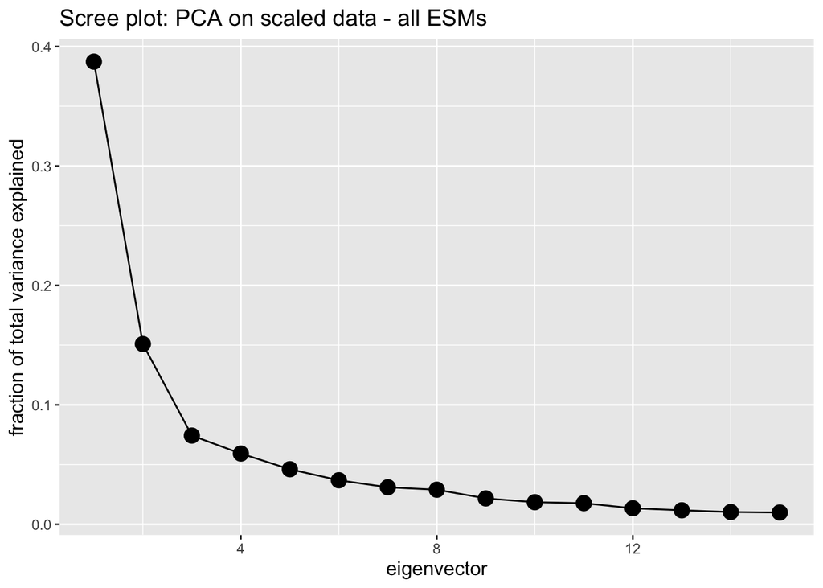

```r
pfull <- var_explained_df %>%
    filter(PC <=15)%>%
  ggplot(aes(x=PC,y=var_explained, group=1))+
  geom_point(size=4)+
  geom_line()+
  labs(title="Scree plot: PCA on scaled data - all ESMs") +
    xlab('eigenvector') + ylab('fraction of total variance explained') +
    theme(axis.title = element_text(size = axis_size),
          plot.title = element_text(size = title_size))

ggsave(paste0(fig_dir, 'scree_fulldata.png'), pfull, width = 8, height = 6, units = 'in')
ggsave(paste0(fig_dir, 'scree_fulldata.jpg'), pfull, width = 8, height = 6, units = 'in')

pfull
```

-> first five eigenvalues focus

# compare coefficients in full PCA space

from the set of available coefficients in the full PCA space, select models whose coefficients span the space in the sense of:

- every ESM is ‘close enough’ to one of the selected models in terms of L2 distance of coefficients
- Con: have to decide on a cutoff
- Making sure each oosESM-Exp combo being similar to one chosenESM-Exp combo

## functionalized

```r
get_subset_data <- function(esmsubset, fulldata){
    as.data.frame(fulldata) %>%
        mutate(temp = row.names(.)) %>%
        separate(temp, into=c('esm', 'trash'), sep = '~', extra='merge') %>%
        filter(esm %in% esmsubset) %>%
        select(-esm, -trash) %>%
        as.matrix(.) ->
        subdata

    return(subdata)
}


full_pca_distances <- function(subset_esms, fullpca, n_eigenvalues = 5){

    coeff <- as.data.frame(fullpca$x[,1:n_eigenvalues])

    # reshape so have info by ESM and experiment
    coeff %>%
        mutate(id = row.names(.)) %>%
        separate(id, into = c('esm', 'scenario', 'ensemble'), sep ='~') %>%
        gather(pc, value, -esm, -scenario, -ensemble) -> # %>%
        # spread(scenario, value) ->
        coeff_all_ESM

    # pull off the subset coefficients into their own DF for comparison
    coeff_all_ESM %>%
        filter(esm %in% subset_esms)  %>%
        spread(scenario, value) ->
        coeff_sub_ESM

    out <- data.frame()
    for (esmname in unique(coeff_all_ESM$esm)){

        # only calculate for oos ESMs
        if(!(esmname %in% subset_esms)){

            coeff_all_ESM %>%
                filter(esm == esmname) ->
                oos

            # For each subset ESM, compare each oos scenario with all 4 scenarios
            # and record the smallest. Then have a data frame with how close each
            # subset ESM can get to each scenario of the oos ESM.
            oos %>%
                left_join(coeff_sub_ESM %>%
                              select(-ensemble) %>%
                              rename(subset_ESM = esm),
                          by = 'pc') %>%
                group_by(esm, scenario, ensemble, subset_ESM) %>%
                summarise(closest_L2 = min( sqrt(sum((value-ssp126)^2)),
                                            sqrt(sum((value-ssp245)^2)),
                                            sqrt(sum((value-ssp370)^2)),
                                            sqrt(sum((value-ssp585)^2))))  %>%
                ungroup %>%
                # Then filter to just the closest of any subset ESM
                # on each oos scenario
                group_by(esm, scenario, ensemble) %>%
                filter(closest_L2 == min(closest_L2)) %>%
                ungroup %>%
                bind_rows(out, .) ->
                out
            }        # end calculation for each subset esm

        } # end loop over all ESMs

    # take average L2 for all oos esms - that's the characteristic value for this
    # particular subset. Then pick the subset that has smallest characteristic value.

    return(data.frame(avg_closest_L2 = mean(out$closest_L2)))

}


########
```

# all subsets

```r
nESMs <- 5

# Get the set of all possible combinations of 5 ESMs
region_summary %>%
    select(esm) %>%
    distinct %>%
    filter(!(esm %in% non_candidate_esm)) ->
    df

as.data.frame(t(apply(combn(nrow(df), nESMs),
                      2, function(i) df[i,])
                )
              ) %>%
    mutate(subset_id = paste0('subset', as.integer(row.names(.)))) %>%
    gather(trash, subset, -subset_id) %>%
    select(-trash) %>%
    arrange(subset_id) ->
    table_of_subsets
write.csv(table_of_subsets, paste0(write_dir,'subsets_22choose5.csv'), row.names = FALSE)

# Same data but reshaped
table_of_subsets <- read.csv(paste0(write_dir,'subsets_22choose5.csv'))
table_of_subsets %>%
    mutate(mod = as.integer(row.names(.)) %% 5,
           esm=paste0('esm', mod)) %>%
    select(-mod) %>%
    spread(esm, subset) %>%
    mutate(id = paste(esm1, esm2, esm3, esm4, esm0, sep='~')) ->
    table_of_subsets2

# Table of ECS preserving subsets
ecs_subsets <- read.csv("additional_data/five_sample_esm_climate_sensitivity.csv",
                        stringsAsFactors = F)
ecs_subsets %>%
    mutate(id = paste(esm1, esm2, esm3, esm4, esm5, sep='~')) %>%
    gather(esm_id, esm, -cs1, -cs2, -cs3, -cs4, -cs5, -id ) %>%
    gather(cs_id, cs, -esm_id, -esm, -id) %>%
    mutate(esm_id2 = substr(esm_id, nchar(esm_id), nchar(esm_id)),
           cs_id2 = substr(cs_id, nchar(cs_id), nchar(cs_id))) %>%
    filter(esm_id2 == cs_id2) %>%
    select(-esm_id, -cs_id, -esm_id2, -cs_id2) %>%
    arrange(id) %>%
    left_join(table_of_subsets2 %>% select(subset_id, id), by = 'id') %>%
    select(subset_id, esm, cs) %>%
    rename(subset=esm) %>%
    na.omit()->
    ecs_subsets_clean
```

```r
# For every subset, calculate the metrics
metrics <- data.frame()
i <- 1
for (subsetid in unique(table_of_subsets$subset_id)){
    print(subsetid)
    print(i)

    subset <- table_of_subsets[table_of_subsets['subset_id']==subsetid,]$subset

    get_subset_data(esmsubset = subset,
                    fulldata = full_data) ->
        subdata

    sub_pca <- prcomp(subdata, center=TRUE, scale = TRUE)

    data.frame(subset_id = subsetid,
               coeff_metric = suppressWarnings(suppressMessages(full_pca_distances(subset_esms = subset,
                                                 fullpca = full_pca,
                                                 n_eigenvalues = 5)))) %>%
        bind_rows(metrics, .)->
        metrics

    rm(subset)
    rm(subdata)
    rm(sub_pca)

    i <- i+1

}

write.csv(metrics, paste0(write_dir,'esm_subsets_metrics_22choose5.csv'), row.names = FALSE)
```

# Take a look at minimizing sets of ESMs

```r
# Metrics for every subset with IDs
metrics <- read.csv(paste0(write_dir,'esm_subsets_metrics_22choose5.csv')) %>%
    rename(coefficient_metric = avg_closest_L2)

# Table of all subsets with IDs
table_of_subsets <- read.csv(paste0(write_dir,'subsets_22choose5.csv'))
table_of_subsets %>%
    mutate(mod = as.integer(row.names(.)) %% 5,
           esm=paste0('esm', mod)) %>%
    select(-mod) %>%
    spread(esm, subset) %>%
    mutate(id = paste(esm1, esm2, esm3, esm4, esm0, sep='~')) ->
    table_of_subsets2

# Table of ECS preserving subsets
ecs_subsets <- read.csv("additional_data/five_sample_esm_climate_sensitivity.csv",
                        stringsAsFactors = F)
ecs_subsets %>%
    mutate(id = paste(esm1, esm2, esm3, esm4, esm5, sep='~')) %>%
    gather(esm_id, esm, -cs1, -cs2, -cs3, -cs4, -cs5, -id ) %>%
    gather(cs_id, cs, -esm_id, -esm, -id) %>%
    mutate(esm_id2 = substr(esm_id, nchar(esm_id), nchar(esm_id)),
           cs_id2 = substr(cs_id, nchar(cs_id), nchar(cs_id))) %>%
    filter(esm_id2 == cs_id2) %>%
    select(-esm_id, -cs_id, -esm_id2, -cs_id2) %>%
    arrange(id) %>%
    left_join(table_of_subsets2 %>% select(subset_id, id), by = 'id') %>%
    select(subset_id, esm, cs) %>%
    rename(subset=esm) %>%
    na.omit() ->
    ecs_subsets_clean
```

## minimize across all possible combinations

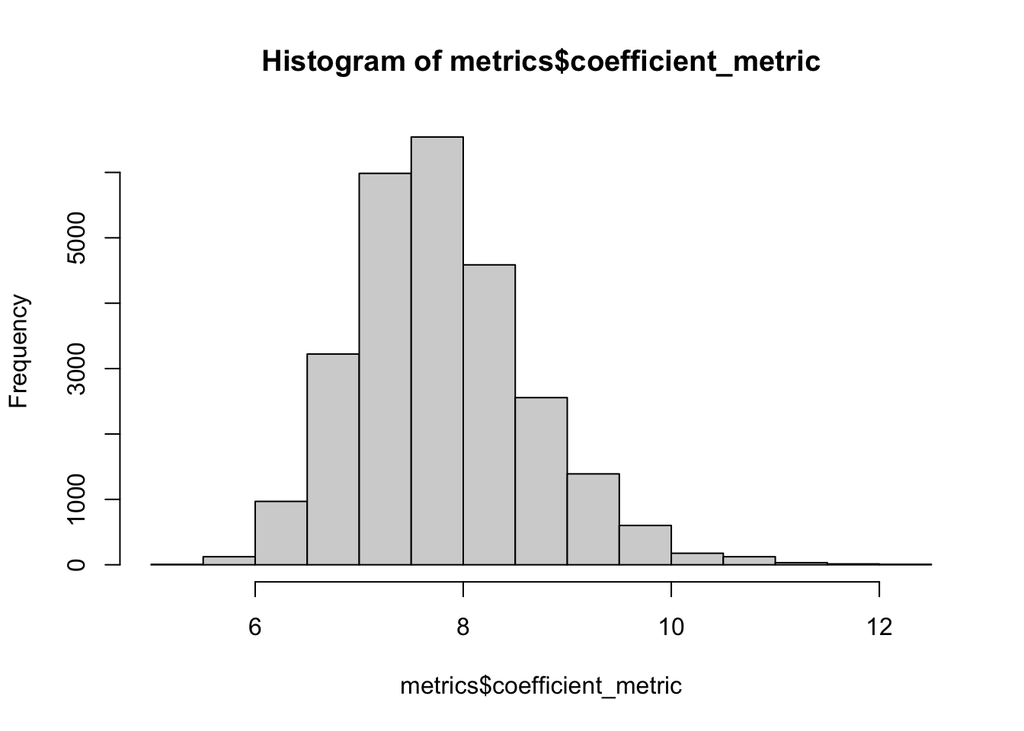

```r
# Subset that is minimum in the projection metric across all possible subsets
metrics %>%
    filter(coefficient_metric == min(coefficient_metric)) %>%
    left_join(table_of_subsets, by = c('subset_id')) ->
    coefficient_min
hist(metrics$coefficient_metric)
```

```r
knitr::kable(coefficient_min)
```

| subset_id | avg_nrms_across_esms | coefficient_metric | subset |
| --- | --- | --- | --- |
| subset11961 | 0.6273168 | 5.404571 | BCC-CSM2-MR |
| subset11961 | 0.6273168 | 5.404571 | CESM2 |
| subset11961 | 0.6273168 | 5.404571 | CMCC-ESM2 |
| subset11961 | 0.6273168 | 5.404571 | MRI-ESM2-0 |
| subset11961 | 0.6273168 | 5.404571 | UKESM1-0-LL |

## minimize across ECS-distribution

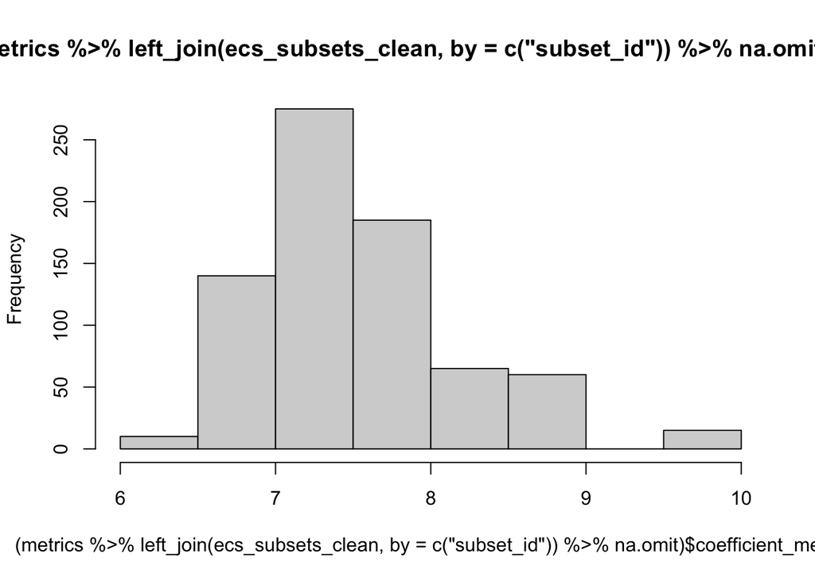

```r
# Subset that is minimum in the projection metric across all possible subsets
metrics %>%
    left_join(ecs_subsets_clean, by = c('subset_id')) %>%
    na.omit %>%
    filter(coefficient_metric == min(coefficient_metric)) ->
    coefficient_min


hist((metrics %>%
    left_join(ecs_subsets_clean, by = c('subset_id')) %>%
    na.omit)$coefficient_metric)
```

```r
knitr::kable(coefficient_min)
```

| subset_id | avg_nrms_across_esms | coefficient_metric | subset | cs |
| --- | --- | --- | --- | --- |
| subset159 | 0.7677227 | 6.355302 | ACCESS-CM2 | 4.7 |
| subset159 | 0.7677227 | 6.355302 | ACCESS-ESM1-5 | 3.9 |
| subset159 | 0.7677227 | 6.355302 | BCC-CSM2-MR | 3.0 |
| subset159 | 0.7677227 | 6.355302 | MIROC6 | 2.6 |
| subset159 | 0.7677227 | 6.355302 | MRI-ESM2-0 | 3.2 |

## plotting in full PCA space

```r
full_pca$x %>%
  as.data.frame() %>%
  mutate(id = row.names(.)) %>%
  separate(id, into=c('model', 'scenario', 'ensemble'), sep = '~') %>%
  select(model, scenario, PC1, PC2, PC3, PC4, PC5)->
  coordinates
```

### all PCs

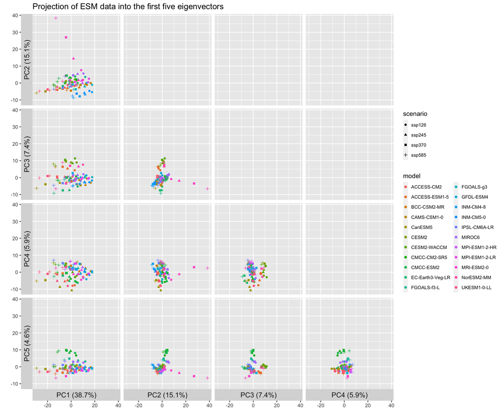

```r
coordinates %>%
    gather(pc_x, pc_x_val, -model, -scenario)  %>%
    left_join(coordinates %>%
                  gather(pc_y, pc_y_val, -model, -scenario),
               by = c('model', 'scenario'))  %>%
    mutate(x_id = as.integer(substr(pc_x, nchar(pc_x), nchar(pc_x))),
           y_id = as.integer(substr(pc_y, nchar(pc_y), nchar(pc_y)))) %>%
    filter(y_id > x_id) %>%
    # add frac variance explained by each PC to labels:
    left_join(var_explained_df %>%
                  mutate(PC = paste0('PC', PC),
                         var_explained = round(100*var_explained,
                                               digits = 1)),
              by = c('pc_x' = 'PC')) %>%
    mutate(pc_x = paste0(pc_x, ' (',var_explained, '%)'))   %>%
    select(-var_explained) %>%
    left_join(var_explained_df %>%
                  mutate(PC = paste0('PC', PC),
                         var_explained = round(100*var_explained,
                                               digits = 1)),
              by = c('pc_y' = 'PC')) %>%
    mutate(pc_y = paste0(pc_y, ' (',var_explained, '%)'))   %>%
    select(-var_explained) ->
    grid_plot
p_coefs <- ggplot(data = grid_plot) +
    geom_point(mapping = aes(x = pc_x_val, y = pc_y_val,
                             color = model, shape = scenario)) +
    #  geom_point(data = grid_plot %>% filter(model %in% coefficient_min$subset),
    #            mapping = aes(x = pc_x_val, y = pc_y_val, color = model, shape = scenario),
    #            size = 2) +
    ggtitle('Projection of ESM data into the first five eigenvectors') +
    facet_grid(pc_y ~ pc_x, switch = 'both') +
    theme(strip.text = element_text(size = axis_size),
          plot.title = element_text(size=title_size),
          legend.text = element_text(size = axis_size-4),
          legend.key.width = unit(0.3, 'cm')) +
    xlab('') + ylab('')

ggsave(paste0(fig_dir, 'full_data_coeff_grid_plot.png'), width = 8, height =6, units = 'in')
ggsave(paste0(fig_dir, 'full_data_coeff_grid_plot.jpg'), width = 8, height =6, units = 'in')

p_coefs
```

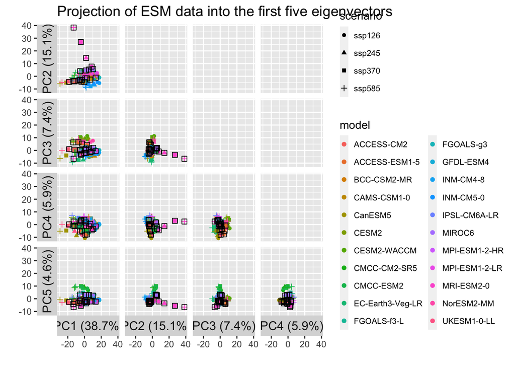

```r
p_coefs <- ggplot(data = grid_plot) +
    geom_point(mapping = aes(x = pc_x_val, y = pc_y_val,
                             color = model, shape = scenario)) +
     geom_point(data = grid_plot %>% filter(model %in% coefficient_min$subset),
               mapping = aes(x = pc_x_val, y = pc_y_val),
               color = 'black', shape = 0, size = 2) +
    ggtitle('Projection of ESM data into the first five eigenvectors') +
    facet_grid(pc_y ~ pc_x, switch = 'both') +
    theme(strip.text = element_text(size = axis_size),
          plot.title = element_text(size=title_size),
          legend.text = element_text(size = axis_size-4),
          legend.key.width = unit(0.3, 'cm')) +
    xlab('') + ylab('')

ggsave(paste0(fig_dir, 'full_data_coeff_grid_plot_subset.png'), width = 8, height =6, units = 'in')
ggsave(paste0(fig_dir, 'full_data_coeff_grid_plot_subset.jpg'), width = 8, height =6, units = 'in')

p_coefs
```

# Validation

## basic summary values

```r
as.data.frame(full_data) %>%
    mutate(id = row.names(.)) %>%
    separate(id, into = c('esm', 'scenario', 'ensemble') , sep = '~') %>%
    gather(metric, value, -esm, -scenario, -ensemble) %>%
    separate(metric, into = c('region', 'metric'), sep = '~') %>%
    spread(metric, value)->
    full_df

full_df %>%
    filter(esm %in% coefficient_min$subset) ->
    sub_df



full_df %>%
    group_by(region) %>%
    summarize(cmip_pr_end_anomaly_pct = mean(pr_end_anomaly_pct),
              cmip_pr_iasd = mean(pr_iasd),
              cmip_pr_mid_anomaly_pct = mean(pr_mid_anomaly_pct),
              cmip_tas_end_anomaly = mean(tas_end_anomaly),
              cmip_tas_iasd = mean(tas_iasd),
              cmip_tas_mid_anomaly = mean(tas_mid_anomaly)) %>%
    ungroup ->
    full_summary

sub_df %>%
    group_by(region) %>%
    summarize(sub_pr_end_anomaly_pct = mean(pr_end_anomaly_pct),
              sub_pr_iasd = mean(pr_iasd),
              sub_pr_mid_anomaly_pct = mean(pr_mid_anomaly_pct),
              sub_tas_end_anomaly = mean(tas_end_anomaly),
              sub_tas_iasd = mean(tas_iasd),
              sub_tas_mid_anomaly = mean(tas_mid_anomaly)) %>%
    ungroup ->
    sub_summary


full_summary %>%
    left_join(sub_summary, by = 'region') %>%
    mutate(diff_pr_end_anomaly_pct = cmip_pr_end_anomaly_pct-sub_pr_end_anomaly_pct,
           diff_pr_iasd = cmip_pr_iasd-sub_pr_iasd,
           diff_pr_mid_anomaly_pct = cmip_pr_mid_anomaly_pct-sub_pr_mid_anomaly_pct,
           diff_tas_end_anomaly = cmip_tas_end_anomaly-sub_tas_end_anomaly,
           diff_tas_iasd = cmip_tas_iasd-sub_tas_iasd,
           diff_tas_mid_anomaly = cmip_tas_mid_anomaly-sub_tas_mid_anomaly) ->
     compare

max(abs(compare$diff_pr_end_anomaly_pct))
```

```
## [1] 0.1025214
```

```r
max(abs(compare$diff_pr_iasd))
```

```
## [1] 1.131961e-06
```

```r
max(abs(compare$diff_pr_mid_anomaly_pct))
```

```
## [1] 0.04349838
```

```r
max(abs(compare$diff_tas_end_anomaly))
```

```
## [1] 0.2323388
```

```r
max(abs(compare$diff_tas_iasd))
```

```
## [1] 0.1125657
```

```r
max(abs(compare$diff_tas_mid_anomaly))
```

```
## [1] 0.3092634
```

## HS notes

- Hawkins and Sutton 09/Lehner2020: do for full data, do for final subset of ESMs and compare?

From Lehner https://esd.copernicus.org/articles/11/491/2020/esd-11-491-2020.pdf

- T and P globally and regionally over time; and gridded for time slices
1. the model uncertainty M is calculated as the variance across the ensemble means of the seven SMILEs (i.e., across the forced responses of the SMILEs).
2. internal variability uncertainty I is calculated as the variance across ensemble members of a given SMILE, yielding one estimate of I per model. Prior to this calculation, time series are smoothed with the running mean corresponding to the target metric (here mostly decadal means). Averaging across the seven I values yields the multimodel mean internal variability uncertainty Imean. Alternatively, to explore the assumption that Imean does not change over time, we use the 1950–2014 average value of Imean throughout the calculation (i.e., Ifixed). We also use the model with the largest and smallest I , i.e., Imax and Imin, to quantify the e influence of model uncertainty in the estimate of I.
3. Following HS09, we calculate S as the variance across the multimodel means calculated for the different emissions scenarios, using a consistent set of available models.

Then how do I want to apply that to our IPCC regional metrics (ideally) or the full time series